# 57 | 观察者模式（下）：如何实现一个异步非阻塞的EventBus框架？

[figure not shown]

# 57 | 观察者模式（下）：如何实现一个异步非阻塞的EventBus框架？

2020-03-13 王争

设计模式之美

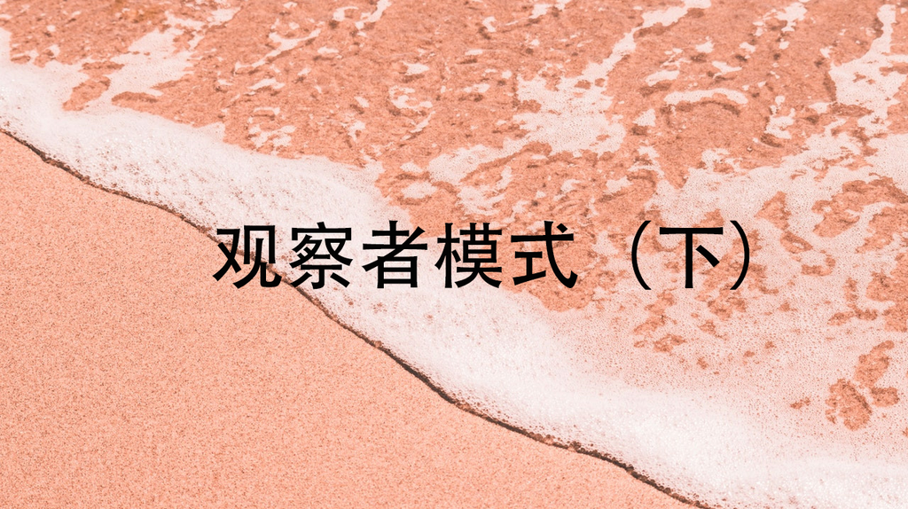

### 讲述：冯永吉

[interactive chart not shown]

上一节课中，我们学习了观察者模式的原理、实现、应用场景，重点介绍了不同应用场景下，几种不同的实现方式，包括：同步阻塞、异步非阻塞、进程内、进程间的实现方式。

同步阻塞是最经典的实现方式，主要是为了代码解耦；异步非阻塞除了能实现代码解耦之外，还能提高代码的执行效率；进程间的观察者模式解耦更加彻底，一般是基于消息队列来实现，用来实现不同进程间的被观察者和观察者之间的交互。

今天，我们聚焦于异步非阻塞的观察者模式，带你实现一个类似 Google Guava EventBus 的通用框架。等你学完本节课之后，你会发现，实现一个框架也并非一件难事。

话不多说，让我们正式开始今天的学习吧！

## 异步非阻塞观察者模式的简易实现

上一节课中，我们讲到，对于异步非阻塞观察者模式，如果只是实现一个简易版本，不考虑任何通用性、复用性，实际上是非常容易的。

我们有两种实现方式。其中一种是：在每个 handleRegSuccess() 函数中创建一个新的线程执行代码逻辑；另一种是：在 UserController 的 register() 函数中使用线程池来执行每个观察者的 handleRegSuccess() 函数。两种实现方式的具体代码如下所示：

// 第一种实现方式，其他类代码不变，就没有再重复罗列

public class RegPromotionObserver implements RegObserver {

private PromotionService promotionService; // 依赖注入

@Override

public void handleRegSuccess(long userId) {

Thread thread = new Thread(new Runnable() {

@Override

public void run() {

promotionService.issueNewUserExperienceCash(userId);

}

});

thread.start();

}

}

// 第二种实现方式，其他类代码不变，就没有再重复罗列

public class UserController {

private UserService userService; // 依赖注入

private List<RegObserver> regObservers = new ArrayList<>();

private Executor executor;

public UserController(Executor executor) {

this.executor = executor;

}

public void setRegObservers(List<RegObserver> observers) {

regObservers.addAll(observers);

}

public Long register(String telephone, String password) {

//省略输入参数的校验代码

//省略userService.register()异常的try-catch代码

long userId = userService.register(telephone, password);

for (RegObserver observer : regObservers) {

executor.execute(new Runnable() {

@Override

public void run() {

observer.handleRegSuccess(userId);

}

});

}

return userId;

}

}

对于第一种实现方式，频繁地创建和销毁线程比较耗时，并且并发线程数无法控制，创建过多的线程会导致堆栈溢出。第二种实现方式，尽管利用了线程池解决了第一种实现方式的问题，但线程池、异步执行逻辑都耦合在了 register() 函数中，增加了这部分业务代码的维护成本。

如果我们的需求更加极端一点，需要在同步阻塞和异步非阻塞之间灵活切换，那就要不停地修改 UserController 的代码。除此之外，如果在项目中，不止一个业务模块需要用到异步非阻塞观察者模式，那这样的代码实现也无法做到复用。

我们知道，框架的作用有：隐藏实现细节，降低开发难度，做到代码复用，解耦业务与非业务代码，让程序员聚焦业务开发。针对异步非阻塞观察者模式，我们也可以将它抽象成框架来达到这样的效果，而这个框架就是我们这节课要讲的 EventBus。

## EventBus 框架功能需求介绍

EventBus 翻译为“事件总线”，它提供了实现观察者模式的骨架代码。我们可以基于此框架，非常容易地在自己的业务场景中实现观察者模式，不需要从零开始开发。其中，Google Guava EventBus 就是一个比较著名的 EventBus 框架，它不仅仅支持异步非阻塞模式，同时也支持同步阻塞模式

现在，我们就通过例子来看一下，Guava EventBus 具有哪些功能。还是上节课那个用户注册的例子，我们用 Guava EventBus 重新实现一下，代码如下所示：

public class UserController {

private UserService userService; // 依赖注入

private EventBus eventBus;

private static final int DEFAULT_EVENTBUS_THREAD_POOL_SIZE = 20;

public UserController() {

//eventBus = new EventBus(); // 同步阻塞模式

eventBus = new AsyncEventBus(Executors.newFixedThreadPool(DEFAULT_EVENTBUS_THREAD_POOL_SIZE)); // 异步非阻塞模式

}

public void setRegObservers(List<Object> observers) {

for (Object observer : observers) {

eventBus.register(observer);

}

}

public Long register(String telephone, String password) {

//省略输入参数的校验代码

//省略userService.register()异常的try-catch代码

long userId = userService.register(telephone, password);

eventBus.post(userId);

return userId;

}

}

public class RegPromotionObserver {

private PromotionService promotionService; // 依赖注入

@Subscribe

public void handleRegSuccess(long userId) {

promotionService.issueNewUserExperienceCash(userId);

}

}

public class RegNotificationObserver {

private NotificationService notificationService;

@Subscribe

public void handleRegSuccess(long userId) {

notificationService.sendInboxMessage(userId, "...");

}

}

利用 EventBus 框架实现的观察者模式，跟从零开始编写的观察者模式相比，从大的流程上来说，实现思路大致一样，都需要定义 Observer，并且通过 register() 函数注册 Observer，也都需要通过调用某个函数（比如，EventBus 中的 post() 函数）来给 Observer 发送消息（在 EventBus 中消息被称作事件 event）。

但在实现细节方面，它们又有些区别。基于 EventBus，我们不需要定义 Observer 接口，任意类型的对象都可以注册到 EventBus 中，通过 @Subscribe 注解来标明类中哪个函数可以接收被观察者发送的消息。

接下来，我们详细地讲一下，Guava EventBus 的几个主要的类和函数。

EventBus、AsyncEventBus

Guava EventBus 对外暴露的所有可调用接口，都封装在 EventBus 类中。其中，EventBus 实现了同步阻塞的观察者模式，AsyncEventBus 继承自 EventBus，提供了异步非阻塞的观察者模式。具体使用方式如下所示：

EventBus eventBus = new EventBus(); // 同步阻塞模式

EventBus eventBus = new AsyncEventBus(Executors.newFixedThreadPool(8))；// 异步阻塞模式

register() 函数

EventBus 类提供了 register() 函数用来注册观察者。具体的函数定义如下所示。它可以接受任何类型（Object）的观察者。而在经典的观察者模式的实现中，register() 函数必须接受实现了同一 Observer 接口的类对象。

public void register(Object object);

unregister() 函数

相对于 register() 函数，unregister() 函数用来从 EventBus 中删除某个观察者。我就不多解释了，具体的函数定义如下所示：

public void unregister(Object object);

post() 函数

EventBus 类提供了 post() 函数，用来给观察者发送消息。具体的函数定义如下所示：

public void post(Object event);

比如，AObserver 能接收的消息类型是 XMsg，BObserver 能接收的消息类型是 YMsg，CObserver 能接收的消息类型是 ZMsg。其中，XMsg 是 YMsg 的父类。当我们如下发送消息的时候，相应能接收到消息的可匹配观察者如下所示：

XMsg xMsg = new XMsg();

YMsg yMsg = new YMsg();

ZMsg zMsg = new ZMsg();

post(zMsg); => CObserver接收到消息

你可能会问，每个 Observer 能接收的消息类型是在哪里定义的呢？我们来看下 Guava EventBus 最特别的一个地方，那就是 @Subscribe 注解。

@Subscribe 注解

EventBus 通过 @Subscribe 注解来标明，某个函数能接收哪种类型的消息。具体的使用代码如下所示。在 DObserver 类中，我们通过 @Subscribe 注解了两个函数 f1()、f2()。

public DObserver {

//...省略其他属性和方法...

@Subscribe

public void f1(PMsg event) { //... }

@Subscribe

public void f2(QMsg event) { //... }

}

当通过 register() 函数将 DObserver 类对象注册到 EventBus 的时候，EventBus 会根据 @Subscribe 注解找到 f1() 和 f2()，并且将两个函数能接收的消息类型记录下来（PMsg->f1，QMsg->f2）。当我们通过 post() 函数发送消息（比如 QMsg 消息）的时候，EventBus 会通过之前的记录（QMsg->f2），调用相应的函数（f2）。

## 手把手实现一个 EventBus 框架

Guava EventBus 的功能我们已经讲清楚了，总体上来说，还是比较简单的。接下来，我们就重复造轮子，“山寨”一个 EventBus 出来。

我们重点来看，EventBus 中两个核心函数 register() 和 post() 的实现原理。弄懂了它们，基本上就弄懂了整个 EventBus 框架。下面两张图是这两个函数的实现原理图。

[figure not shown]

[figure not shown]

从图中我们可以看出，最关键的一个数据结构是 Observer 注册表，记录了消息类型和可接收消息函数的对应关系。当调用 register() 函数注册观察者的时候，EventBus 通过解析 @Subscribe 注解，生成 Observer 注册表。当调用 post() 函数发送消息的时候，EventBus 通过注册表找到相应的可接收消息的函数，然后通过 Java 的反射语法来动态地创建对象、执行函数。对于同步阻塞模式，EventBus 在一个线程内依次执行相应的函数。对于异步非阻塞模式，EventBus 通过一个线程池来执行相应的函数。

弄懂了原理，实现起来就简单多了。整个小框架的代码实现包括 5 个类：EventBus、AsyncEventBus、Subscribe、ObserverAction、ObserverRegistry。接下来，我们依次来看下这 5 个类。

### 1.Subscribe

Subscribe 是一个注解，用于标明观察者中的哪个函数可以接收消息。

@Retention(RetentionPolicy.RUNTIME)

@Target(ElementType.METHOD)

@Beta

public @interface Subscribe {}

### 2.ObserverAction

ObserverAction 类用来表示 @Subscribe 注解的方法，其中，target 表示观察者类，method 表示方法。它主要用在 ObserverRegistry 观察者注册表中。

public class ObserverAction {

private Object target;

private Method method;

public ObserverAction(Object target, Method method) {

this.target = Preconditions.checkNotNull(target);

this.method = method;

this.method.setAccessible(true);

}

public void execute(Object event) { // event是method方法的参数

try {

method.invoke(target, event);

} catch (InvocationTargetException | IllegalAccessException e) {

e.printStackTrace();

}

}

}

### 3.ObserverRegistry

ObserverRegistry 类就是前面讲到的 Observer 注册表，是最复杂的一个类，框架中几乎所有的核心逻辑都在这个类中。这个类大量使用了 Java 的反射语法，不过代码整体来说都不难理解，其中，一个比较有技巧的地方是 CopyOnWriteArraySet 的使用。

CopyOnWriteArraySet，顾名思义，在写入数据的时候，会创建一个新的 set，并且将原始数据 clone 到新的 set 中，在新的 set 中写入数据完成之后，再用新的 set 替换老的 set。这样就能保证在写入数据的时候，不影响数据的读取操作，以此来解决读写并发问题。除此之外，CopyOnWriteSet 还通过加锁的方式，避免了并发写冲突。具体的作用你可以去查看一下 CopyOnWriteSet 类的源码，一目了然。

public class ObserverRegistry {

private ConcurrentMap<Class<?>, CopyOnWriteArraySet<ObserverAction>> registry = new ConcurrentHashMap<>();

public void register(Object observer) {

Map<Class<?>, Collection<ObserverAction>> observerActions = findAllObserverActions(observer);

for (Map.Entry<Class<?>, Collection<ObserverAction>> entry : observerActions.entrySet()) {

Class<?> eventType = entry.getKey();

Collection<ObserverAction> eventActions = entry.getValue();

CopyOnWriteArraySet<ObserverAction> registeredEventActions = registry.get(eventType);

if (registeredEventActions == null) {

registry.putIfAbsent(eventType, new CopyOnWriteArraySet<>());

registeredEventActions = registry.get(eventType);

}

registeredEventActions.addAll(eventActions);

}

}

public List<ObserverAction> getMatchedObserverActions(Object event) {

List<ObserverAction> matchedObservers = new ArrayList<>();

Class<?> postedEventType = event.getClass();

for (Map.Entry<Class<?>, CopyOnWriteArraySet<ObserverAction>> entry : registry.entrySet()) {

Class<?> eventType = entry.getKey();

Collection<ObserverAction> eventActions = entry.getValue();

if (postedEventType.isAssignableFrom(eventType)) {

matchedObservers.addAll(eventActions);

}

}

return matchedObservers;

}

private Map<Class<?>, Collection<ObserverAction>> findAllObserverActions(Object observer) {

Map<Class<?>, Collection<ObserverAction>> observerActions = new HashMap<>();

Class<?> clazz = observer.getClass();

for (Method method : getAnnotatedMethods(clazz)) {

Class<?>[] parameterTypes = method.getParameterTypes();

Class<?> eventType = parameterTypes[0];

if (!observerActions.containsKey(eventType)) {

observerActions.put(eventType, new ArrayList<>());

}

observerActions.get(eventType).add(new ObserverAction(observer, method));

}

return observerActions;

}

private List<Method> getAnnotatedMethods(Class<?> clazz) {

List<Method> annotatedMethods = new ArrayList<>();

for (Method method : clazz.getDeclaredMethods()) {

if (method.isAnnotationPresent(Subscribe.class)) {

Class<?>[] parameterTypes = method.getParameterTypes();

Preconditions.checkArgument(parameterTypes.length == 1,

"Method %s has @Subscribe annotation but has %s parameters."

+ "Subscriber methods must have exactly 1 parameter.",

method, parameterTypes.length);

annotatedMethods.add(method);

}

}

return annotatedMethods;

}

}

### 4.EventBus

EventBus 实现的是阻塞同步的观察者模式。看代码你可能会有些疑问，这明明就用到了线程池 Executor 啊。实际上，MoreExecutors.directExecutor() 是 Google Guava 提供的工具类，看似是多线程，实际上是单线程。之所以要这么实现，主要还是为了跟 AsyncEventBus 统一代码逻辑，做到代码复用。

public class EventBus {

private Executor executor;

private ObserverRegistry registry = new ObserverRegistry();

public EventBus() {

this(MoreExecutors.directExecutor());

}

protected EventBus(Executor executor) {

this.executor = executor;

}

public void register(Object object) {

registry.register(object);

}

public void post(Object event) {

List<ObserverAction> observerActions = registry.getMatchedObserverActions(event);

for (ObserverAction observerAction : observerActions) {

executor.execute(new Runnable() {

@Override

public void run() {

observerAction.execute(event);

}

});

}

}

}

### 5.AsyncEventBus

有了 EventBus，AsyncEventBus 的实现就非常简单了。为了实现异步非阻塞的观察者模式，它就不能再继续使用 MoreExecutors.directExecutor() 了，而是需要在构造函数中，由调用者注入线程池。

public class AsyncEventBus extends EventBus {

public AsyncEventBus(Executor executor) {

super(executor);

}

}

至此，我们用了不到 200 行代码，就实现了一个还算凑活能用的 EventBus，从功能上来讲，它跟 Google Guava EventBus 几乎一样。不过，如果去查看Google Guava EventBus 的源码，你会发现，在实现细节方面，相比我们现在的实现，它其实做了很多优化，比如优化了在注册表中查找消息可匹配函数的算法。如果有时间的话，建议你去读一下它的源码。

## 重点回顾

好了，今天的内容到此就讲完了。我们来一块总结回顾一下，你需要重点掌握的内容。

框架的作用有：隐藏实现细节，降低开发难度，做到代码复用，解耦业务与非业务代码，让程序员聚焦业务开发。针对异步非阻塞观察者模式，我们也可以将它抽象成框架来达到这样的效果，而这个框架就是我们这节课讲的 EventBus。EventBus 翻译为“事件总线”，它提供了实现观察者模式的骨架代码。我们可以基于此框架，非常容易地在自己的业务场景中实现观察者模式，不需要从零开始开发。

很多人觉得做业务开发没有技术挑战，实际上，做业务开发也会涉及很多非业务功能的开发，比如今天讲到的 EventBus。在平时的业务开发中，我们要善于抽象这些非业务的、可复用的功能，并积极地把它们实现成通用的框架。

## 课堂讨论

在今天内容的第二个模块“EventBus 框架功能需求介绍”中，我们用 Guava EventBus 重新实现了 UserController，实际上，代码还是不够解耦。UserController 还是耦合了很多跟观察者模式相关的非业务代码，比如创建线程池、注册 Observer。为了让 UserController 更加聚焦在业务功能上，你有什么重构的建议吗？

欢迎留言和我分享你的想法。如果有收获，也欢迎你把这篇文章分享给你的朋友。

[figure not shown]

[figure not shown]

- 小文同学

  2020-03-13

  Guava EventBus 对我来说简直是一份大礼。里面解耦功能使本来的旧项目又不可维护逐渐转化为可维护。  
  EventBus作为一个总线，还考虑了递归传送事件的问题，可以选择广度优先传播和深度优先传播，遇到事件死循环的时候还会报错。Guava的项目对这个模块的封装非常值得我们去阅读，复杂的都在里头，外面极为易用，我拷贝了一份EventBus的代码进行修改以适配自己的项目，发觉里面的构造都极为精密巧妙，像一个机械钟表一样，自己都下不了手，觉得不小心就是弄坏了。  
  跟随真正优秀的工程师，并阅读其写出来的代码让人受益匪浅。

- 下雨天

  2020-03-13

  课后题：  
  代理模式，使用一个代理类专门来处理EventBus相关逻辑。作用：  
  1.将业务与非业务逻辑分离  
  2.后续替换EventBus实现方式直接改写代理类，满足拓展需求

- 辣么大

  2020-03-13

  重构使用代理模式，将非业务代码放到代理类中。  
  另外试了争哥讲的EventBut类，在定义观察者的入参要修改成*Long*类型，如果使用long，这个方法是无法注册的，代码执行收不到通知。应该是ObserverRegistry类需要完善一下。  
  @Subscribe  
  public void handleRegSuccess(Long userId) {  
  System.out.println("handleRegSuccess...");  
  promotionService.issueNewUserExperienceCash(userId);  
  }  
  代码见：https://github.com/gdhucoder/Algorithms4/tree/master/designpattern/u57

[figure not shown]

- 饭

  2020-03-13

  老师，我们主要做物流方面的业务系统，类似仓储，港口这样的，流程繁杂。平时主要就是写增删改查，然后通过一个状态字段变化控制流程，所有业务代码流程中每一步操作都写满了各种状态验证，判断。后期稍微需求变动一点点，涉及到状态改动，要调整流程的话，都是一场灾难。针对我们这种系统，有办法将流程状态解耦出来吗？今天看到这篇事件总线的文章，好像看到希望，但是没想清具体怎么操作。不知道老师怎么看

- Heaven

  2020-03-13

  对于这个问题,在UserCntroller中,我们应该只保留post函数() 发送的相关逻辑,而将注册Observer,初始化EventBus相关逻辑剔除,如果非要使用EventBus来实现的话,我们需要有人帮我们去进行注册和初始化,这时候就可以立马想到之前讲的工厂模式的DI框架,我们可以让所有观察者都被DI框架所管理,并且对EventBus创建一个装饰器类,在这个装饰器类中,由开发者选择注入线程池实现异步发送还是直接使用同步发送的,并且在init函数中 从DI框架管理的对象池中拿出所有标有@Subscribe注解的类,保存到ObserverRegistry中,对于所有需要使用EventBus的类,注入这个装饰器类即可,设计的好,甚至可以做到其他依赖代码都不用改一点

[figure not shown]

- Jeff.Smile

  2020-03-13

  在例子中当eventbus调用post传递的参数中是long userId,而两个observer被subcriber注解的方法参数都一样，此时这两个方法都会被调用到吗？

[figure not shown]

- 右耳听海

  2020-03-17

  给老师点赞，虽然很早就接触了eventbus，但一直没明白这个的设计思想，现在有种醍醐灌顶的感觉

- Geek_76616d

  2020-03-16

  对Guava EventBus相见恨晚啊

  **
- blacknhole

  2020-03-15

  提个问题：  
  文中“所谓可匹配指的是，能接收的消息类型是发送消息（post 函数定义中的 event）类型的子类”这话似乎有问题，应该是父类吧？

[figure not shown]

- 陈玉群

  2020-03-14

  争哥，在EventBus 框架功能需求介绍里面，如果XMsg 是 YMsg 的父类，则post(xMsg); => AObserver、BObserver接收到消息，这个地方应该是如果XMsg 是 YMsg 的子类。

- Frank

  2020-03-14

  为了让 UserController 更加聚焦在业务功能上，我的想法是将耦合的EventBus代码抽取出来形成一个单独的服务类，通过注入的方式注入到UserController类中使用。这样使其两者的职责单一，而新抽取出来的服务类可被其他业务场景复用。  
  今天也加深了对Guava Eventbus的认识，虽然之前专栏也介绍过这个类库的使用。结合Jdk提供的java.util.Observable&Observer观察者模式API，与EventBus进行比对，如果要实现进程内的观察者使用EventBus最为方便。从JDK9之后，java.util.Observable&Observer已被标记为废弃，建议使用Java Beans规范中的事件模式和java.util.concurrent.Flow API。

[figure not shown]

- cricket1981

  2020-03-14

  public void handleRegSuccess(long userId) 方法签名中的long类型应该改成Long类型，不然SubscriberRegistry.getSubscribers(Object event)会匹配不上类型

[figure not shown]

- 爱麻将

  2020-03-14

  最近公司做了个业务系统架构重构，套用了其它公司的业务架构，架构与业务耦合的太紧，做起来非常痛苦，越来越觉得跟争哥写的专栏相违背。

- 小晏子

  2020-03-13

  我的想法比较直接，将UserController中的业务代码提出来放在接口的实现类中，这个UserController可以改名为EventController，然后这个接口实现类注入到这个EventController中，这样业务逻辑和控制逻辑就分离了，示例如下：  
  interface iController {  
  object register()  
  }  
  public class UserControllerService implement iController {  
  private string telphone;  
  private string password;  
  public Long register() {  
  long userId = userService.register(telephone, password);  
  return userId;  
  }  
  }  
  public class EventController {  
  private iController iService;  
  private EventBus eventBus;  
  private static final int DEFAULT_EVENTBUS_THREAD_POOL_SIZE = 20;  
  public EventController() {  
  eventBus = new AsyncEventBus(Executors.newFixedThreadPool(DEFAULT_EVENTBUS_THREAD_POOL_SIZE)); // 异步非阻塞模式  
  }  
  public void setRegObservers(List<Object> observers) {  
  for (Object observer : observers) {  
  eventBus.register(observer);  
  }  
  }  
  public void SendMessage() {  
  object msg = iService.register()  
  eventBus.post(msg)  
  }  
  }

[figure not shown]

- hanazawakana

  2020-03-13

  单独用一个工具类来处理eventbus相关的注册和post操作。然后通过依赖注入传给usercontroller

[figure not shown]

- 1012

  2020-03-13

  UserController 耦合的跟观察者模式相关的非业务代码可以使用代理模式进行重构

- test

  2020-03-13

  课堂讨论：装饰器模式修饰UserController，在装饰器类里面创建线程池，注册Observer。

[figure not shown]

- 让爱随风

  2020-03-13

  XMsg xMsg = new XMsg();  
  YMsg yMsg = new YMsg();  
  ZMsg zMsg = new ZMsg();  
  post(xMsg); => AObserver、BObserver接收到消息  
  post(yMsg); => BObserver接收到消息  
  post(zMsg); => CObserver接收到消息  
  感觉这个是不是不对啊，感觉应该是：  
  XMsg xMsg = new XMsg();  
  YMsg yMsg = new YMsg();  
  ZMsg zMsg = new ZMsg();  
  post(xMsg); => AObserver 接收到消息  
  post(yMsg); => AObserver，BObserver接收到消息  
  post(zMsg); => AObserver，BObserver，CObserver接收到消息

[figure not shown]

- Eden Ma

  2020-03-13

  使用单例作为通知中心将创建线程和注册observer的代码放在里面,将被观察者状态注入到单例类,进而通知观察者.

[figure not shown]

- Ken张云忠

  2020-03-13

  UserController 还是耦合了很多跟观察者模式相关的非业务代码，比如创建线程池、注册 Observer。为了让 UserController 更加聚焦在业务功能上，你有什么重构的建议吗？  
  创建一个UserSubject类,将线程创建和注册Observer逻辑封装在进该类型,再通过依赖注入方式注入到UserController,最后UserController只需UserSubject的post函数就可以发送消息了.

[interactive chart not shown]